# MiBici: Data Analysis of Public Bike Use

Author: SQJ | *Last Updated: April 24th 2024*  
Georgia Tech Master of Science in Analytics | CSE6040 Spring 2024

### Overview

[MiBici](https://mibici.net/) (*translated as MyBike in english*) is a public bike service used in my home city of Guadalajara, Jalisco, Mexico. This service is used in Guadalajara's Metropolitan Area, which has a population of 5,268,642 (as of 2020) distributed in eight main municipalities and a total area of 2,543.13 squared km (981.91 squared mi).

This service has established stations where users can take and return a public bike, all they need is to sign up through MiBici's platform and pay a charge for 1, 3, 7 days, or annual use. After signing up, users get a transport card that can be used at any station in Guadalajara's Metropolitan Area.

MiBici makes their data public and has published it every month since December 2014.

This notebook includes sections for **data cleaning and transformation**, **exploratory data analysis (EDA)**, **data visualization**, and **statistical analysis**.

### Objective

The aim of this notebook is to analyse public bike use data in Guadalajara's Metropolitan Area and answer the following questions:

1. How many bike trips have been registered?
2. How many users have used the service?
3. What is the mean amount of trips per user?
4. What are the demographic charactristics of users (age, sex) and how does bike use vary between groups?
5. What are the minimum, mean, and maximum times of bike trips?
6. What are the most and least used stations?
7. What are the most and least occuring trips between destinations?

### Data

Data was obtained directly from [MiBici's public data website](https://www.mibici.net/es/datos-abiertos/). In this site, data is published in CSV files corresponding to individuals month from December 2014 to March 2024 (datasets range from 1.5 to 33.2 MB). A dataset is also available with the information of the bike stations themselves.

*Note: Due to this assignment's 10 MB limit on dataset size, this analysis will focus on only one month of pubic bike use, in this case the most recent month within this size constraint, which is April 2020 (8.9 MB).*

Dataset 1 - 'datos_abiertos_2020_04.csv' (*translates to open_data_2020_04.csv in english*)

[output not shown]

Dataset 2 - 'nomenclatura_2024_03.csv' (*translates to nomenclature_2024_03.csv in english*)

```
Data of bike stations in Guadalajar's Metropolitan Area.
```

*One final note before getting started, I have cleaned, transformed, and combined all datasets from Dec 2014 to Mar 2024 and published the final dataset (2.51 GB) in [Kaggle](https://www.kaggle.com/datasets/sebastianquirarte/over-9-years-of-real-public-bike-use-data-mibici?select=mibici_2014-2024), this is not part of this analysis but is available if anyone is interested.*

### Results

# Proyect

## Importing Data

To start of, we'll import necessary libraries and set some parameters that will be useful throughout this notebook.

```python
import datetime # supplies classes for manipulating dates and times
from matplotlib import pyplot as plt # static, animated, and interactive visualizations in Python
import pandas as pd # data manipulation, analysis, structures and operations for manipulating numerical tables and time series
import seaborn as sns # data visualization based on matplotlib, provides a high-level interface for statistical graphics
```

Now, we'll load in the data from both datasets by reading their corresponding CSV files as dataframes.

```python
# Load in bike use data
bike_use = pd.read_csv('datos_abiertos_2020_04.csv')

# View first and last few rows of dataframe
bike_use
```

|  | Viaje_Id | Usuario_Id | Genero | Año_de_nacimiento | Inicio_del_viaje | Fin_del_viaje | Origen_Id | Destino_Id |
| --- | --- | --- | --- | --- | --- | --- | --- | --- |
| 0 | 15657768 | 644732 | M | 1993.0 | 2020-04-01 06:01:23 | 2020-04-01 06:08:02 | 271 | 78 |
| 1 | 15657769 | 275652 | M | 1978.0 | 2020-04-01 06:01:24 | 2020-04-01 06:06:37 | 40 | 52 |
| 2 | 15657770 | 627563 | M | 1998.0 | 2020-04-01 06:01:46 | 2020-04-01 06:11:05 | 276 | 274 |
| 3 | 15657771 | 142506 | M | 1988.0 | 2020-04-01 06:01:47 | 2020-04-01 06:18:01 | 165 | 183 |
| 4 | 15657772 | 615400 | M | 1997.0 | 2020-04-01 06:02:14 | 2020-04-01 06:07:47 | 265 | 157 |
| ... | ... | ... | ... | ... | ... | ... | ... | ... |
| 129271 | 15828560 | 632442 | M | 1979.0 | 2020-04-30 23:49:01 | 2020-05-01 00:17:46 | 51 | 51 |
| 129272 | 15828561 | 51032 | M | 1990.0 | 2020-04-30 23:52:01 | 2020-05-01 00:05:00 | 47 | 60 |
| 129273 | 15828562 | 62720 | F | 1989.0 | 2020-04-30 23:53:43 | 2020-05-01 00:05:08 | 25 | 25 |
| 129274 | 15828563 | 661265 | M | 1976.0 | 2020-04-30 23:54:58 | 2020-05-01 00:05:35 | 73 | 204 |
| 129275 | 15828564 | 634527 | M | 1977.0 | 2020-04-30 23:59:19 | 2020-05-01 00:10:29 | 16 | 48 |

129276 rows × 8 columns

Let's translate the column names from spanish to english for clarity.

```python
# Rename column names in place, without creating a copy of the dataframe
bike_use.rename(columns = {'Viaje_Id': 'Trip_Id',
                           'Usuario_Id': 'User_Id',
                           'Genero': 'Sex',
                           'Año_de_nacimiento': 'Birth_year',
                           'Inicio_del_viaje': 'Trip_start',
                           'Fin_del_viaje': 'Trip_end',
                           'Origen_Id': 'Origin_Id',
                           'Destino_Id': 'Destination_Id'},
                            inplace = True)
```

```python
# Load in bike station data
stations = pd.read_csv('nomenclatura_2024_03.csv', encoding = 'latin1') # encoding = 'latin1' to correctly load latin characters

# View first (head) and last (tail) few rows of dataframe
stations
```

|  | id | name | obcn | location | latitude | longitude | status |
| --- | --- | --- | --- | --- | --- | --- | --- |
| 0 | 2 | (GDL-001) C. Epigmenio Glez./ Av. 16 de Sept. | GDL-001 | POLÍGONO CENTRAL | 20.666378 | -103.348820 | IN_SERVICE |
| 1 | 3 | (GDL-002) C. Colonias / Av. Niños héroes | GDL-002 | POLÍGONO CENTRAL | 20.667228 | -103.366000 | IN_SERVICE |
| 2 | 4 | (GDL-003) C. Vidrio / Av. Chapultepec | GDL-003 | POLÍGONO CENTRAL | 20.667690 | -103.368252 | IN_SERVICE |
| 3 | 5 | (GDL-004) C. Ghilardi /C. Miraflores | GDL-004 | POLÍGONO CENTRAL | 20.691750 | -103.362550 | IN_SERVICE |
| 4 | 6 | (GDL-005) C. San Diego /Calzada Independencia | GDL-005 | POLÍGONO CENTRAL | 20.681158 | -103.339363 | IN_SERVICE |
| ... | ... | ... | ... | ... | ... | ... | ... |
| 367 | 384 | (GDL-252) C. Calpulalpan / C. Independencia | GDL-252 | POLÍGONO CENTRAL | 20.678006 | -103.341808 | IN_SERVICE |
| 368 | 385 | (GDL-246)Juan José Baz/Silvestre Revueltas | GDL-246 | POLÍGONO CENTRAL | 20.691523 | -103.340601 | IN_SERVICE |
| 369 | 386 | (GDL-254)Porfirio Díaz/Francisco Javier Mina | GDL-254 | POLÍGONO CENTRAL | 20.670670 | -103.324521 | IN_SERVICE |
| 370 | 387 | (GDL-267)Gral. Arteaga/Fray Antonio Alcalde | GDL-267 | POLÍGONO CENTRAL | 20.697044 | -103.335557 | IN_SERVICE |
| 371 | 388 | (GDL-253) C. General Salazar / C. Federación | GDL-253 | POLÍGONO CENTRAL | 20.679572 | -103.336661 | IN_SERVICE |

372 rows × 7 columns

## Data cleaning and transformation

Do the datasets contain any null values? If so, let's remove the rows with empty cells.

```python
# Count rows with null values
print(f"""bike_use dataframe:

{bike_use.isna().sum()}

stations dataframe:

{stations.isna().sum()}
""")
```

```
bike_use dataframe:

Trip_Id            0
User_Id            0
Sex               88
Birth_year        91
Trip_start         0
Trip_end           0
Origin_Id          0
Destination_Id     0
dtype: int64

stations dataframe:

id           0
name         0
obcn         0
location     0
latitude     0
longitude    0
status       0
dtype: int64
```

```python
# Remove rows with null values from bike_use dataframe
bike_use = bike_use.dropna()
```

91 rows with empty data were removed from the *bike_use* dataframe and the *stations* dataframe contained no null values.

Aside from removing null values, another fundamental step when cleaning datasets is to make sure the data type of each variable makes sense and is useful. This can be done using the *dtypes* method. Let's first check out the *bike_use* dataframe.

```python
# View data type of all variables (columns) of dataframe
bike_use.dtypes
```

```
Trip_Id             int64
User_Id             int64
Sex                object
Birth_year        float64
Trip_start         object
Trip_end           object
Origin_Id           int64
Destination_Id      int64
dtype: object
```

```python
# Disable chained assignments (avoids warning when changing data types)
pd.options.mode.chained_assignment = None

# Changing data types
bike_use['Sex'] = bike_use['Sex'].astype('category') # Sex as category
bike_use['Birth_year'] = bike_use['Birth_year'].astype('int') # Birth year as integer
bike_use['Trip_start'] = pd.to_datetime(bike_use['Trip_start'], format = '%Y-%m-%d %H:%M:%S.%f') # Trip start as datetime
bike_use['Trip_end'] = pd.to_datetime(bike_use['Trip_end'], format = '%Y-%m-%d %H:%M:%S.%f') # Trip end as datetime

# View data type of all variables (columns) of dataframe
bike_use.dtypes
```

```
Trip_Id                    int64
User_Id                    int64
Sex                     category
Birth_year                 int64
Trip_start        datetime64[ns]
Trip_end          datetime64[ns]
Origin_Id                  int64
Destination_Id             int64
dtype: object
```

Now let's repeat the process for the *stations* dataframe.

```python
# View data type of all variables (columns) of dataframe
stations.dtypes
```

```
id             int64
name          object
obcn          object
location      object
latitude     float64
longitude    float64
status        object
dtype: object
```

```python
# Changing data types
stations['status'] = stations['status'].astype('category') # status as category

# View data type of all variables (columns) of dataframe
stations.dtypes
```

```
id              int64
name           object
obcn           object
location       object
latitude      float64
longitude     float64
status       category
dtype: object
```

Now that null values have been removed and data types trasnformed, some useful variables to calculate are **age** (*2020 - Birth_year*) and **trip duration** (*Trip_end - Trip_start*).

```python
# Calculate age
bike_use['Age'] = 2020 - bike_use['Birth_year']

# Calculate trip duration
bike_use['Duration'] = bike_use['Trip_end'] - bike_use['Trip_start']

# Duration in seconds
bike_use['Duration (sec)'] = bike_use['Duration'].dt.total_seconds().astype("int")

# View updated dataframe
bike_use
```

|  | Trip_Id | User_Id | Sex | Birth_year | Trip_start | Trip_end | Origin_Id | Destination_Id | Age | Duration | Duration (sec) |
| --- | --- | --- | --- | --- | --- | --- | --- | --- | --- | --- | --- |
| 0 | 15657768 | 644732 | M | 1993 | 2020-04-01 06:01:23 | 2020-04-01 06:08:02 | 271 | 78 | 27 | 0 days 00:06:39 | 399 |
| 1 | 15657769 | 275652 | M | 1978 | 2020-04-01 06:01:24 | 2020-04-01 06:06:37 | 40 | 52 | 42 | 0 days 00:05:13 | 313 |
| 2 | 15657770 | 627563 | M | 1998 | 2020-04-01 06:01:46 | 2020-04-01 06:11:05 | 276 | 274 | 22 | 0 days 00:09:19 | 559 |
| 3 | 15657771 | 142506 | M | 1988 | 2020-04-01 06:01:47 | 2020-04-01 06:18:01 | 165 | 183 | 32 | 0 days 00:16:14 | 974 |
| 4 | 15657772 | 615400 | M | 1997 | 2020-04-01 06:02:14 | 2020-04-01 06:07:47 | 265 | 157 | 23 | 0 days 00:05:33 | 333 |
| ... | ... | ... | ... | ... | ... | ... | ... | ... | ... | ... | ... |
| 129271 | 15828560 | 632442 | M | 1979 | 2020-04-30 23:49:01 | 2020-05-01 00:17:46 | 51 | 51 | 41 | 0 days 00:28:45 | 1725 |
| 129272 | 15828561 | 51032 | M | 1990 | 2020-04-30 23:52:01 | 2020-05-01 00:05:00 | 47 | 60 | 30 | 0 days 00:12:59 | 779 |
| 129273 | 15828562 | 62720 | F | 1989 | 2020-04-30 23:53:43 | 2020-05-01 00:05:08 | 25 | 25 | 31 | 0 days 00:11:25 | 685 |
| 129274 | 15828563 | 661265 | M | 1976 | 2020-04-30 23:54:58 | 2020-05-01 00:05:35 | 73 | 204 | 44 | 0 days 00:10:37 | 637 |
| 129275 | 15828564 | 634527 | M | 1977 | 2020-04-30 23:59:19 | 2020-05-01 00:10:29 | 16 | 48 | 43 | 0 days 00:11:10 | 670 |

129185 rows × 11 columns

The day of the week of each trip can be determined using the datetime function *weekday( )*. **0 = Monday, 1 = Tuesday, ... , 6 = Sunday**.

```python
# Weekday of each trip
bike_use['Weekday'] = bike_use['Trip_start'].dt.day_name()
# Make weekday column categorical
bike_use['Weekday'] = bike_use['Weekday'].astype("category")

# View updated dataframe
bike_use
```

|  | Trip_Id | User_Id | Sex | Birth_year | Trip_start | Trip_end | Origin_Id | Destination_Id | Age | Duration | Duration (sec) | Weekday |
| --- | --- | --- | --- | --- | --- | --- | --- | --- | --- | --- | --- | --- |
| 0 | 15657768 | 644732 | M | 1993 | 2020-04-01 06:01:23 | 2020-04-01 06:08:02 | 271 | 78 | 27 | 0 days 00:06:39 | 399 | Wednesday |
| 1 | 15657769 | 275652 | M | 1978 | 2020-04-01 06:01:24 | 2020-04-01 06:06:37 | 40 | 52 | 42 | 0 days 00:05:13 | 313 | Wednesday |
| 2 | 15657770 | 627563 | M | 1998 | 2020-04-01 06:01:46 | 2020-04-01 06:11:05 | 276 | 274 | 22 | 0 days 00:09:19 | 559 | Wednesday |
| 3 | 15657771 | 142506 | M | 1988 | 2020-04-01 06:01:47 | 2020-04-01 06:18:01 | 165 | 183 | 32 | 0 days 00:16:14 | 974 | Wednesday |
| 4 | 15657772 | 615400 | M | 1997 | 2020-04-01 06:02:14 | 2020-04-01 06:07:47 | 265 | 157 | 23 | 0 days 00:05:33 | 333 | Wednesday |
| ... | ... | ... | ... | ... | ... | ... | ... | ... | ... | ... | ... | ... |
| 129271 | 15828560 | 632442 | M | 1979 | 2020-04-30 23:49:01 | 2020-05-01 00:17:46 | 51 | 51 | 41 | 0 days 00:28:45 | 1725 | Thursday |
| 129272 | 15828561 | 51032 | M | 1990 | 2020-04-30 23:52:01 | 2020-05-01 00:05:00 | 47 | 60 | 30 | 0 days 00:12:59 | 779 | Thursday |
| 129273 | 15828562 | 62720 | F | 1989 | 2020-04-30 23:53:43 | 2020-05-01 00:05:08 | 25 | 25 | 31 | 0 days 00:11:25 | 685 | Thursday |
| 129274 | 15828563 | 661265 | M | 1976 | 2020-04-30 23:54:58 | 2020-05-01 00:05:35 | 73 | 204 | 44 | 0 days 00:10:37 | 637 | Thursday |
| 129275 | 15828564 | 634527 | M | 1977 | 2020-04-30 23:59:19 | 2020-05-01 00:10:29 | 16 | 48 | 43 | 0 days 00:11:10 | 670 | Thursday |

129185 rows × 12 columns

## Exploratory Data Analysis (EDA)

We can use the *shape* method to output the size of both dataframes.

```python
print(f"bike_use datafame has {bike_use.shape[0]} rows and {bike_use.shape[1]} columns.")
print(f"stations datafame has {stations.shape[0]} rows and {stations.shape[1]} columns.")
```

```
bike_use datafame has 129185 rows and 12 columns.
stations datafame has 372 rows and 7 columns.
```

The *describe()* funciton allows us to view some descriptive statistics of our data.

```python
bike_use[['Age', 'Duration', 'Duration (sec)']].describe()
```

|  | Age | Duration | Duration (sec) |
| --- | --- | --- | --- |
| count | 129185.000000 | 129185 | 129185.000000 |
| mean | 33.927546 | 0 days 00:11:15.023462476 | 675.023462 |
| std | 10.590707 | 0 days 00:13:50.046540826 | 830.046541 |
| min | 17.000000 | 0 days 00:00:02 | 2.000000 |
| 25% | 26.000000 | 0 days 00:05:47 | 347.000000 |
| 50% | 31.000000 | 0 days 00:09:38 | 578.000000 |
| 75% | 40.000000 | 0 days 00:14:49 | 889.000000 |
| max | 103.000000 | 0 days 23:11:46 | 83506.000000 |

```python
# Calculate unique users
unique_users = len(bike_use['User_Id'].unique())

# Calculate average trips per user
avg_trips = round((bike_use.shape[0] / unique_users), 2)

# Display values
print(f"The dataset contains {bike_use.shape[0]} total bike trips, {unique_users} unique users and an average of {avg_trips} trips per user.")
```

```
The dataset contains 129185 total bike trips, 8169 unique users and an average of 15.81 trips per user.
```

Let's also analyse our data by sex.

```python
total = bike_use.shape[0]

# Count trips by male and female
male = len(bike_use[bike_use['Sex'] == 'M'])
male_percent = round((male / total) * 100, 2)
female = len(bike_use[bike_use['Sex'] == 'F'])
female_percent = round((female / total) * 100, 2)

# Display values
print(f"Out of {total} trips, {male} ({male_percent}%) were registred by male users and {female} ({female_percent}%) by female users.")
```

```
Out of 129185 trips, 99267 (76.84%) were registred by male users and 29918 (23.16%) by female users.
```

## Data Visualization

Let's take a look at the distribution of age and trip duration as a whole and by sex.

```
[Text(0.5, 1.0, 'Figure 2. Histogram of Age by Sex')]
```

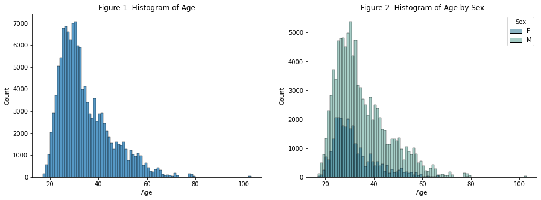

```python
fig, axes = plt.subplots(1, 2, figsize = (15, 5))

# Histogram of age
sns.histplot(bike_use,
            x = "Age",
            # bin size is max value - min value in this case 103 - 17 = 86
            bins = 86,
            ax = axes[0]).set(title = "Figure 1. Histogram of Age") # title

# Histogram of age by sex
sns.histplot(bike_use,
            x = "Age",
            bins = 86,
            hue = "Sex",
            palette = 'crest_r',
            ax = axes[1]).set(title = "Figure 2. Histogram of Age by Sex") # title
```

```
(0.0, 3600.0)
```

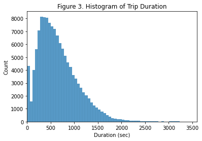

```python
# Histogram of trip duration
sns.histplot(bike_use,
            x = "Duration (sec)",
            bins = 1500).set(title = "Figure 3. Histogram of Trip Duration") # title

plt.xlim(0, 3600) # Trips of up to 1 hour (3600 seconds)
```

```
(0.0, 3600.0)
```

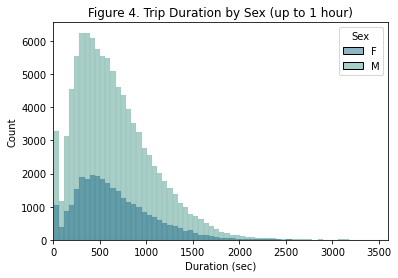

```python
# Histogram of trip duration by sex
sns.histplot(bike_use,
             x = "Duration (sec)",
             bins = 1500,
             hue = "Sex",
             palette = 'crest_r').set(title = "Figure 4. Trip Duration by Sex (up to 1 hour)")

plt.xlim(0, 3600) # trips of up to 1 hour (3600 seconds)
```

```
(0.0, 1200.0)
```

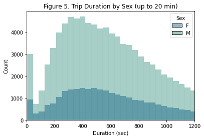

```python
# Histogram of trip duration by sex
sns.histplot(bike_use,
             x = "Duration (sec)",
             bins = 2000,
             hue = "Sex",
             palette = 'crest_r').set(title = "Figure 5. Trip Duration by Sex (up to 20 min)") # title

plt.xlim(0, 1200) # trips of up to 20 min (1,200 seconds)
```

```
(0.0, 240.0)
```

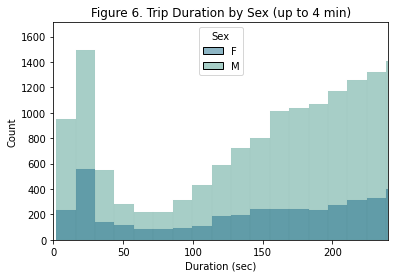

```python
# Histogram of trip duration by sex
sns.histplot(bike_use,
            x = "Duration (sec)",
            bins = 6000,
            hue = "Sex",
            palette = 'crest_r').set(title = "Figure 6. Trip Duration by Sex (up to 4 min)") # title

plt.xlim(0, 240) # trips of up to 4 min (240 seconds)
```

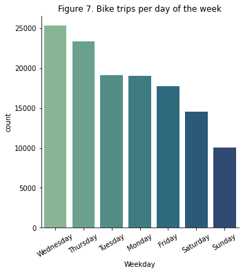

```python
# Bar graph of day of week
plot = sns.catplot(data = bike_use,
                   x = "Weekday",
                   kind = "count",
                   palette = 'crest',
                   order = bike_use['Weekday'].value_counts(ascending = False).index)

plot.set_xticklabels(rotation=30)
plot.set(title = "Figure 7. Bike trips per day of the week") # title
```

From the previous plot we can see that most bike trips took place on Wednesdays, and there were overall more trips during weekdays than weekends.

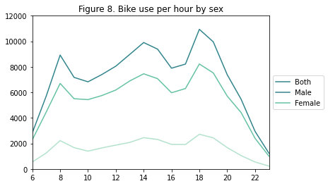

```python
bike_use_hour = bike_use['Trip_start'].dt.hour

bike_use_hour.dtypes

bike_use_hour = bike_use_hour.value_counts()
bike_use_hour = pd.DataFrame(bike_use_hour)

sns.lineplot(data = bike_use_hour,
             palette = "crest").set(title = "Figure 8. Bike use per hour by sex") # title

plt.xlim(6, 23)
plt.ylim(0, 12000)

bike_use_male = bike_use[bike_use['Sex'] == 'M']
bike_use_hour = bike_use_male['Trip_start'].dt.hour

bike_use_hour.dtypes

bike_use_hour = bike_use_hour.value_counts()
bike_use_hour = pd.DataFrame(bike_use_hour)

sns.lineplot(data = bike_use_hour,
             palette = 'BuGn')

bike_use_male = bike_use[bike_use['Sex'] == 'F']
bike_use_hour = bike_use_male['Trip_start'].dt.hour

bike_use_hour.dtypes

bike_use_hour = bike_use_hour.value_counts()
bike_use_hour = pd.DataFrame(bike_use_hour)

sns.lineplot(data = bike_use_hour,
             palette = "Pastel2")

# Put a legend to the right of the current axis
plt.legend(loc='center left', bbox_to_anchor=(1, 0.5),
           labels=['Both', 'Male', 'Female'])
```

Peaks of bike use were registered at 8am, 2pm, and 6pm, which aligns with typical working schedules from 9am to 5pm with lunch taken usually between 1-3pm. Both male and female users follow show similar peaks.

## Data Analysis

First of all, let's review how our dataframe looks.

```python
# View dataframe
bike_use
```

|  | Trip_Id | User_Id | Sex | Birth_year | Trip_start | Trip_end | Origin_Id | Destination_Id | Age | Duration | Duration (sec) | Weekday |
| --- | --- | --- | --- | --- | --- | --- | --- | --- | --- | --- | --- | --- |
| 0 | 15657768 | 644732 | M | 1993 | 2020-04-01 06:01:23 | 2020-04-01 06:08:02 | 271 | 78 | 27 | 0 days 00:06:39 | 399 | Wednesday |
| 1 | 15657769 | 275652 | M | 1978 | 2020-04-01 06:01:24 | 2020-04-01 06:06:37 | 40 | 52 | 42 | 0 days 00:05:13 | 313 | Wednesday |
| 2 | 15657770 | 627563 | M | 1998 | 2020-04-01 06:01:46 | 2020-04-01 06:11:05 | 276 | 274 | 22 | 0 days 00:09:19 | 559 | Wednesday |
| 3 | 15657771 | 142506 | M | 1988 | 2020-04-01 06:01:47 | 2020-04-01 06:18:01 | 165 | 183 | 32 | 0 days 00:16:14 | 974 | Wednesday |
| 4 | 15657772 | 615400 | M | 1997 | 2020-04-01 06:02:14 | 2020-04-01 06:07:47 | 265 | 157 | 23 | 0 days 00:05:33 | 333 | Wednesday |
| ... | ... | ... | ... | ... | ... | ... | ... | ... | ... | ... | ... | ... |
| 129271 | 15828560 | 632442 | M | 1979 | 2020-04-30 23:49:01 | 2020-05-01 00:17:46 | 51 | 51 | 41 | 0 days 00:28:45 | 1725 | Thursday |
| 129272 | 15828561 | 51032 | M | 1990 | 2020-04-30 23:52:01 | 2020-05-01 00:05:00 | 47 | 60 | 30 | 0 days 00:12:59 | 779 | Thursday |
| 129273 | 15828562 | 62720 | F | 1989 | 2020-04-30 23:53:43 | 2020-05-01 00:05:08 | 25 | 25 | 31 | 0 days 00:11:25 | 685 | Thursday |
| 129274 | 15828563 | 661265 | M | 1976 | 2020-04-30 23:54:58 | 2020-05-01 00:05:35 | 73 | 204 | 44 | 0 days 00:10:37 | 637 | Thursday |
| 129275 | 15828564 | 634527 | M | 1977 | 2020-04-30 23:59:19 | 2020-05-01 00:10:29 | 16 | 48 | 43 | 0 days 00:11:10 | 670 | Thursday |

129185 rows × 12 columns

```python
# Subset of bike_use dataframe
bike_subset = bike_use[['Trip_start', 'Origin_Id', 'Destination_Id']]

# Finds 'segment groups' which are unique combinations of origin and destination bike stations
segment_groups = bike_subset.groupby(['Origin_Id', 'Destination_Id'], as_index=False)
# Counts segments
segments = segment_groups.count()
segments.rename(columns={'Trip_start': 'Count'}, inplace=True)

# Makes sure all segments are greater that 1
assert (segments['Count'] > 0).all()

# Displays dataframe
segments
```

|  | Origin_Id | Destination_Id | Count |
| --- | --- | --- | --- |
| 0 | 2 | 2 | 57 |
| 1 | 2 | 3 | 16 |
| 2 | 2 | 4 | 3 |
| 3 | 2 | 6 | 1 |
| 4 | 2 | 8 | 2 |
| ... | ... | ... | ... |
| 21949 | 302 | 251 | 13 |
| 21950 | 302 | 258 | 1 |
| 21951 | 302 | 267 | 2 |
| 21952 | 302 | 270 | 2 |
| 21953 | 302 | 302 | 11 |

21954 rows × 3 columns

Now let's find the 10 most and least frequent origin and destination stations.

```python
# Origin stations
origins = pd.DataFrame(bike_subset['Origin_Id'].value_counts()).rename_axis().reset_index()
origins.rename(columns = {'index': 'Station_Id', 'Origin_Id': 'Count'}, inplace = True)

# Most frequent stations useas as trip origin
print('\nMost frequent stations used as trip origin:')
origins.head(10)
```

```
Most frequent stations used as trip origin:
```

|  | Station_Id | Count |
| --- | --- | --- |
| 0 | 51 | 1995 |
| 1 | 271 | 1850 |
| 2 | 11 | 1726 |
| 3 | 35 | 1719 |
| 4 | 52 | 1707 |
| 5 | 50 | 1563 |
| 6 | 260 | 1512 |
| 7 | 54 | 1493 |
| 8 | 173 | 1416 |
| 9 | 272 | 1354 |

```python
# Least frequent stations useas as trip origin
print('\nLeast frequent stations used as trip origin:')
origins.tail(10).iloc[::-1] # Reverses index order to show values in descending order
```

```
Least frequent stations used as trip origin:
```

|  | Station_Id | Count |
| --- | --- | --- |
| 273 | 294 | 13 |
| 272 | 220 | 30 |
| 271 | 129 | 32 |
| 270 | 257 | 41 |
| 269 | 217 | 44 |
| 268 | 240 | 49 |
| 267 | 115 | 51 |
| 266 | 144 | 55 |
| 265 | 140 | 58 |
| 264 | 101 | 59 |

```python
# Destination stations
destinations = pd.DataFrame(bike_subset['Destination_Id'].value_counts()).rename_axis().reset_index()
destinations.rename(columns = {'index': 'Station_Id', 'Destination_Id': 'Count'}, inplace = True)

# Most frequent stations useas as trip origin
print('\nMost frequent stations used as trip destination:')
destinations.head(10)
```

```
Most frequent stations used as trip destination:
```

|  | Station_Id | Count |
| --- | --- | --- |
| 0 | 51 | 2856 |
| 1 | 35 | 1930 |
| 2 | 271 | 1825 |
| 3 | 260 | 1685 |
| 4 | 52 | 1653 |
| 5 | 11 | 1640 |
| 6 | 54 | 1567 |
| 7 | 50 | 1548 |
| 8 | 256 | 1504 |
| 9 | 272 | 1441 |

```python
# Least frequent stations used as trip origin
print('\nLeast frequent stations used as trip destination:')
destinations.tail(10).iloc[::-1] # Reverses index order to show values in descending order
```

```
Least frequent stations used as trip destination:
```

|  | Station_Id | Count |
| --- | --- | --- |
| 273 | 220 | 28 |
| 272 | 115 | 29 |
| 271 | 129 | 33 |
| 270 | 294 | 34 |
| 269 | 140 | 37 |
| 268 | 205 | 39 |
| 267 | 217 | 41 |
| 266 | 257 | 45 |
| 265 | 144 | 47 |
| 264 | 221 | 50 |

Now let's consider the total interactions that each station had (*origin + destination*) to determine the most and least used stations.

```python
# Create new DataFrame with Station_Id, origin counts, and destination counts
total_interactions = pd.merge(origins, destinations, on='Station_Id', how='outer')
# Rename column names
total_interactions.rename(columns = {'Count_x': 'Origin', 'Count_y': 'Destination'}, inplace = True)
# Create column of the sum of Origin + Destination
total_interactions['Total'] = total_interactions['Origin'] + total_interactions['Destination']

total_interactions
```

|  | Station_Id | Origin | Destination | Total |
| --- | --- | --- | --- | --- |
| 0 | 51 | 1995 | 2856 | 4851 |
| 1 | 271 | 1850 | 1825 | 3675 |
| 2 | 11 | 1726 | 1640 | 3366 |
| 3 | 35 | 1719 | 1930 | 3649 |
| 4 | 52 | 1707 | 1653 | 3360 |
| ... | ... | ... | ... | ... |
| 269 | 217 | 44 | 41 | 85 |
| 270 | 257 | 41 | 45 | 86 |
| 271 | 129 | 32 | 33 | 65 |
| 272 | 220 | 30 | 28 | 58 |
| 273 | 294 | 13 | 34 | 47 |

274 rows × 4 columns

It would be useful to add to this dataframe each station's description and coordinates, which we can get from the *nomenclatura_2024_03.csv* file which we loaded previously as a dataframe.

```python
# Rename ID column
stations.rename(columns = {'id': 'Station_Id'}, inplace = True)
# View dataframe
stations
```

|  | Station_Id | name | obcn | location | latitude | longitude | status |
| --- | --- | --- | --- | --- | --- | --- | --- |
| 0 | 2 | (GDL-001) C. Epigmenio Glez./ Av. 16 de Sept. | GDL-001 | POLÍGONO CENTRAL | 20.666378 | -103.348820 | IN_SERVICE |
| 1 | 3 | (GDL-002) C. Colonias / Av. Niños héroes | GDL-002 | POLÍGONO CENTRAL | 20.667228 | -103.366000 | IN_SERVICE |
| 2 | 4 | (GDL-003) C. Vidrio / Av. Chapultepec | GDL-003 | POLÍGONO CENTRAL | 20.667690 | -103.368252 | IN_SERVICE |
| 3 | 5 | (GDL-004) C. Ghilardi /C. Miraflores | GDL-004 | POLÍGONO CENTRAL | 20.691750 | -103.362550 | IN_SERVICE |
| 4 | 6 | (GDL-005) C. San Diego /Calzada Independencia | GDL-005 | POLÍGONO CENTRAL | 20.681158 | -103.339363 | IN_SERVICE |
| ... | ... | ... | ... | ... | ... | ... | ... |
| 367 | 384 | (GDL-252) C. Calpulalpan / C. Independencia | GDL-252 | POLÍGONO CENTRAL | 20.678006 | -103.341808 | IN_SERVICE |
| 368 | 385 | (GDL-246)Juan José Baz/Silvestre Revueltas | GDL-246 | POLÍGONO CENTRAL | 20.691523 | -103.340601 | IN_SERVICE |
| 369 | 386 | (GDL-254)Porfirio Díaz/Francisco Javier Mina | GDL-254 | POLÍGONO CENTRAL | 20.670670 | -103.324521 | IN_SERVICE |
| 370 | 387 | (GDL-267)Gral. Arteaga/Fray Antonio Alcalde | GDL-267 | POLÍGONO CENTRAL | 20.697044 | -103.335557 | IN_SERVICE |
| 371 | 388 | (GDL-253) C. General Salazar / C. Federación | GDL-253 | POLÍGONO CENTRAL | 20.679572 | -103.336661 | IN_SERVICE |

372 rows × 7 columns

```python
# Subset of stations dataframe
stations_subset = stations[['Station_Id', 'name', 'latitude', 'longitude']]

# Add station description (name) and coordinates (latitude, longitude) to the total_interactions dataframe
total_interactions = pd.merge(total_interactions, stations_subset, on='Station_Id')
# View dataframe
total_interactions
```

|  | Station_Id | Origin | Destination | Total | name | latitude | longitude |
| --- | --- | --- | --- | --- | --- | --- | --- |
| 0 | 51 | 1995 | 2856 | 4851 | (GDL-049) Lopez Cotilla/ Marcos Castellanos | 20.674087 | -103.356320 |
| 1 | 271 | 1850 | 1825 | 3675 | (GDL-198) Av. Alcalde / C. Hospital | 20.685040 | -103.347960 |
| 2 | 11 | 1726 | 1640 | 3366 | (GDL-009) Calz. Federalismo/ C. J. Angulo | 20.682077 | -103.353835 |
| 3 | 35 | 1719 | 1930 | 3649 | (GDL-033) Av. Hidalgo / C. Pedro Loza | 20.677419 | -103.347983 |
| 4 | 52 | 1707 | 1653 | 3360 | (GDL-050) C. Pedro Moreno / Calz. Federalismo | 20.675746 | -103.354579 |
| ... | ... | ... | ... | ... | ... | ... | ... |
| 269 | 217 | 44 | 41 | 85 | (GDL-150) C. Asunción / Av. Chapalita | 20.661387 | -103.392533 |
| 270 | 257 | 41 | 45 | 86 | (GDL-184) Ingreso Cucei / Revolución | 20.659581 | -103.324147 |
| 271 | 129 | 32 | 33 | 65 | (ZPN-035) C. San Juan Bosco / Av. San Ignacio | 20.668440 | -103.404950 |
| 272 | 220 | 30 | 28 | 58 | (GDL-153) C. Crepúsculo / Av. Tonantzin | 20.658460 | -103.390920 |
| 273 | 294 | 13 | 34 | 47 | (ZPN-054) Av. J. Parres Arias / C. Ignacio Ja | 20.734410 | -103.380790 |

274 rows × 7 columns

To wrap things up, let's plot the stations and color them by their total interactions.

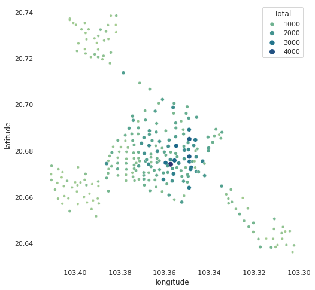

```python
# Figure size and background color (changed from grey to white)
sns.set(rc={"figure.figsize":(8, 8), 'axes.facecolor':'white'}) # width, height

# Scatter plot of bike stations colored by total interactions
sns.scatterplot(data = total_interactions,
                x = 'longitude',
                y = 'latitude',
                hue = 'Total', # color
                size = 'Total', # size
                palette = 'crest')
```

We can see that the most used stations are found around Guadalajara's right-center region, which makes sense since this area is kwon as 'Downtown' which is more densly-populated and has more buisnesses, offices, and cultural settings (restaurants, bars, venues, etc.). Also, least used stations are found at the outskirts of Guadalajara's metropolitan area, which is less densly populated and has less bike stations.

## Possible Improvements

Some possible improrvements to this project include:

- Obtainig climate data (temperature, humidity) and even air quality data and seeing if there is any correlation between the characteristics of each day and it's respective number of bike trips.
- Markov chain analysis to determine most important stations (such as we did in one of the class notebooks in which we analysed airport flight data) and comparing it's results to the most important stations determined in this notebook based on total interactions.
- Creating a scatter plot of bike station use over a real map of Guadalajara and even creating an interactive web application or dashboard that let's you filter by date, age, sex, etc.
- Recreate this analysis with all available bike use data (2014-2024) and not just one month.

Any suggestions, possible improvements, and general comments are greatly appreciated and will be considered. Thank you!